# Text Analysis

## Requirements

**Required File**

**[news.zip](http://guides.lib.unc.edu/ld.php?content_id=41143560)**  
UNZIP the file and move the “news” folder to your working directory (don’t forget to set your working directory!)

**Packages**

Install and load the necessary packages as shown below.

```r
install.packages("tm", repos = "http://cran.us.r-project.org")
install.packages("SnowballC", repos = "http://cran.us.r-project.org")
install.packages("wordcloud", repos = "http://cran.us.r-project.org")

library(tm)
library(SnowballC)
library(wordcloud)
```

## Introduction to Text Analysis

Text analysis (also referred to as text mining) is the process of finding meaningful information from text data. Although the variety of approaches is rapidly widening, at its core, text analysis is concerned with words and their relationships to one another. Words, or **terms** in text analysis are often grouped into **documents**. A collection of documents is refered to as a **corpus**. This structure is a common way of organizing text data.

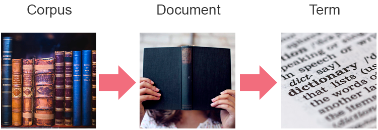

## Creating the Corpus

The “tm” package contains many new functions for working with text data. Our dataset is comprised of news articles published by Reuters during the 1990s. We use the `Corpus()` function to import each of the text files in our dataset as a document into a corpus called “news”.

```r
news <- Corpus(DirSource("news"))
```

## Cleaning Text Data

Text data is notorious for being unstructured and messy, so there are a number of standard methods used for cleaning.

**1. Change case**  
For R and many other programming languages, the word “headline” is not the same as the word “Headline”. Unless we are specifically studying the use of capitalization in our text, we are better off making all of our text lower case.

```r
news <- tm_map(news, content_transformer(tolower))
```

**2. Remove numbers, punctuation and extra white space**  
These transformations take care of what we call “noise” in our text data - elements that aren’t useful for analysis.

```r
news <- tm_map(news, removeNumbers) # Remove numbers
news <- tm_map(news, removePunctuation) # Remove punctuation
news <- tm_map(news, stripWhitespace) # Eliminate extra white spaces
```

**3. Remove stopwords**  
Text analyisis often begins by looking at terms that frequently occur in a corpus. But think about this: which terms are used most often in the English language? The most commonly occuring terms are often the least interesting or meaningful, such as articles (a, an, the) or pronouns (he, she, they). Often, we may want use a **stoplist** to remove these terms from our analysis. The “tm” package comes with stoplists we can use on our corpus.

```r
news <- tm_map(news, removeWords, stopwords("english"))
```

**4. Stemming**  
What if we want to know how often banking is written about in our news articles? We can search for the term “banking” explicitly, but then we will be missing the terms “bank” and “banks”. Sometimes we need to reduce terms to their common roots in order to perform meaningful analysis.

```r
news <- tm_map(news, stemDocument, language = "english")
```

## The Document Term Matrix

Now that we’ve cleaned our text, it’s time to start looking at those term frequencies! We do this by creating a **document-term matrix**. In the document-term matrix, each row represents a different document and each column represents a different term. The number of times a term is used in a document is recorded in the matrix.

For example, let’s say we had two documents that were one sentence each:

**Doc1: Bananas are good.**

**Doc2: Bananas are yellow.**

Our document-term matrix would look like this:

[figure not shown]

We can use the function `DocumentTermMatrix()` to create one for our corpus.

```r
dtm <- DocumentTermMatrix(news)
```

The document-term matrix is a new type of object in r. What happens when we evaluate it?

```r
dtm
```

```
## <<DocumentTermMatrix (documents: 150, terms: 4237)>>
## Non-/sparse entries: 27933/607617
## Sparsity           : 96%
## Maximal term length: 21
## Weighting          : term frequency (tf)
```

We are given some information about our corpus. We have 150 documents and a total of 4,237 terms in all. But what’s all this talk about **sparsity**? Well, the first rows of our matrix look something like this:

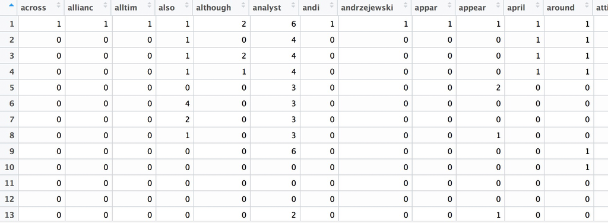

As you can see, most of the cells in the matrix are “0”, or “sparse”. In fact, 96% of our cells are sparse, which is actually not at all unusual.

Because we are working with only 150 documents, we shouldn’t run into too many problems. However, much text analysis is done on corpora with thousands of documents and extremely large matrices. That can severely impact the performance of R and/or our computers! In those situations, it is best to try and reduce the size and sparsity of the document-term matrix. We can accomplish that by removing terms that exist in very few documents. Below, we use the `removeSparseTerms()` function to remove any terms that exist in only 1% of our documents or less.

```r
dtm <- removeSparseTerms(dtm, 0.99)
dtm
```

```
## <<DocumentTermMatrix (documents: 150, terms: 2688)>>
## Non-/sparse entries: 26384/376816
## Sparsity           : 93%
## Maximal term length: 17
## Weighting          : term frequency (tf)
```

## Analyzing the Matrix

Let’s change our DocumentTermMatrix object into a traditional R matrix object so we can do some basic exploration.

```r
dtmx <- as.matrix(dtm)
```

What are the most common terms? In order to answer this question, we need to add up all the cells in our matrix for each term (column). We can do this using the `colSums()` function.

```r
termfreq <- colSums(dtmx)
```

Now, let’s look at the top 20 terms from most frequent to least frequent. We’ll use `sort()` to put our terms in order and `head()` to only view the top 20. We can nest our functions like this:

```r
head(sort(termfreq, decreasing=TRUE), 20)
```

```
##    said    bank percent  market    will    year   manag   crown    fund
##    1130     657     471     385     312     304     249     238     230
##    firm   czech million     one compani    also  invest     new    last
##     217     194     192     191     189     178     171     170     167
## analyst    week
##     165     164
```

What if we want to get the frequency of a specific term? In the 90s, the internet was just starting to take off. To find the frequency of the term “internet”, We can use `sum()` on the column name.

```r
sum(dtmx[,"internet"])
```

```
## [1] 134
```

```r
findAssocs(dtm, "internet", .6)
```

```
## $internet
##    foundat    network    backbon     scienc        mci telecommun
##       0.89       0.88       0.79       0.77       0.73       0.71
##        web       host       user       rout        nsf      everi
##       0.70       0.70       0.69       0.68       0.68       0.67
##      speed     across     provid      video       send      solut
##       0.67       0.64       0.64       0.64       0.64       0.63
##    connect       copi   procedur        inc        net california
##       0.63       0.63       0.62       0.62       0.61       0.61
##     school    traffic
##       0.61       0.60
```

## Word Clouds

A popular visualization for term frequencies is a word cloud, and no introduction to text mining is complete without one! Below, we use the “wordcloud” package to visualize words with frequencies of 100 and higher.

[figure not shown]

```r
wordcloud(names(termfreq), termfreq, min.freq=100, colors=brewer.pal(6,"Dark2"))
```

## Exercises

For this lesson, find a text dataset on the internet and use it to perform your own analysis! You can use the methods described above, or look into some more complex techniques such as [sentiment analysis](https://cran.r-project.org/web/packages/SentimentAnalysis/index.html) or [topic modeling](https://cran.r-project.org/web/packages/topicmodels/index.html). Below are several resources for locating text datasets.

[UCI Machine Learning Repository](https://archive.ics.uci.edu/ml/datasets.html?area=&att=&format=&numAtt=&numIns=&sort=nameUp&task=&type=text&view=table)

[Kaggle](https://www.kaggle.com/datasets?sortBy=relevance&group=featured&search=text)

[NLP Datasets](https://github.com/niderhoff/nlp-datasets)

## [Let us know what you think of this lesson!](https://unc.az1.qualtrics.com/jfe/form/SV_8e1zRY2rlFUYBMx)